# Descriptive Statistics 1: Introduction to Statistics & Describing Data

**Important⚠️ Note for video learners: `{inspectdf}` install instructions have changed**

The package `{inspectdf}` was removed from CRAN and is no longer easily installed in R. Since recording, we’ve created a maintained fork of `{inspectdf}` on GitHub, so all the `inspect_cat()`, `inspect_num()`, `inspect_types()`, and `show_plot()` code in the video still works exactly as shown.

The only difference is how you install the package. Instead of `pacman::p_load(inspectdf)`, use:

```r
pacman::p_load_current_gh("the-graph-courses/inspectdf")
```

This is already included in the setup code at the top of these notes.

# Introduction

In this lesson, we will:

1. Introduce the key **branches of statistics** and their uses.
2. Explore the fundamental concepts of **descriptive analysis**, focusing on:
   - **Types of Variables**: Numerical (continuous, discrete) and Categorical (ordinal, nominal)
   - **Graphical Summaries** for each type.
   - **Numerical Summaries** for categorical variables.

# Learning Objectives

By the end of this lesson, you will be able to:

1. Understand the key branches of statistics: **descriptive** and **inferential**.
2. Explain the aims and methods of **descriptive statistics**.
3. Identify **numerical and categorical variables** and their subtypes.
4. Create appropriate **graphical summaries** for each variable type in R, using {ggplot2}, {visdat}, and {inspectdf}.
5. Create **numerical summaries** for categorical variables.
6. Visually assess **skew and symmetry** in data distributions.

# What is Statistics?

> “The science of collecting, summarising, presenting and interpreting data, and of using them to estimate the magnitude of associations and test hypotheses.” (Kirkwood & Sterne, 2003).

## Two Key Branches of Statistics

**Descriptive statistics** involves the organization, summarization, and display of data (e.g., tables, charts, numerical summary statistics).

**Inferential statistics** involves using *sample data* to draw conclusions about a *population*.

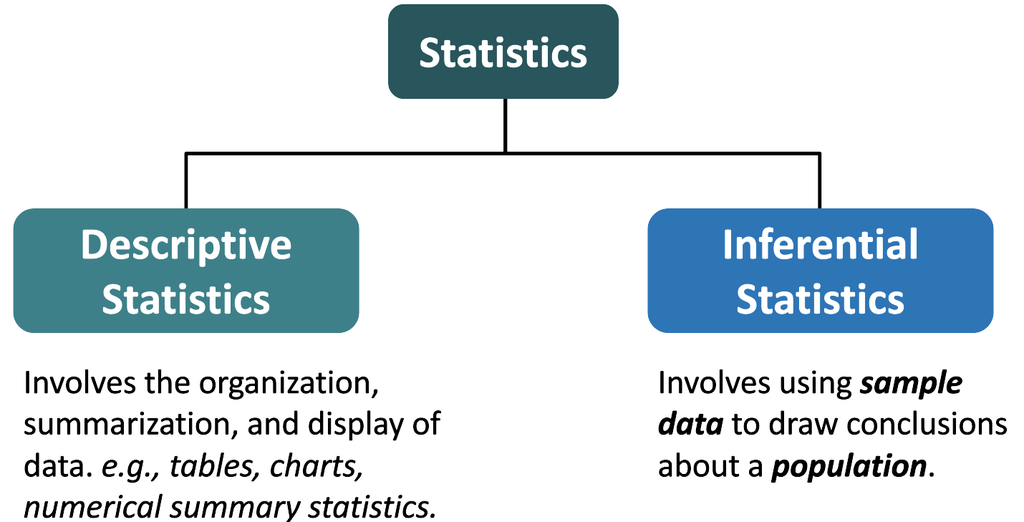

# Population and Samples

Before diving deeper, let’s briefly cover the concepts of populations and samples.

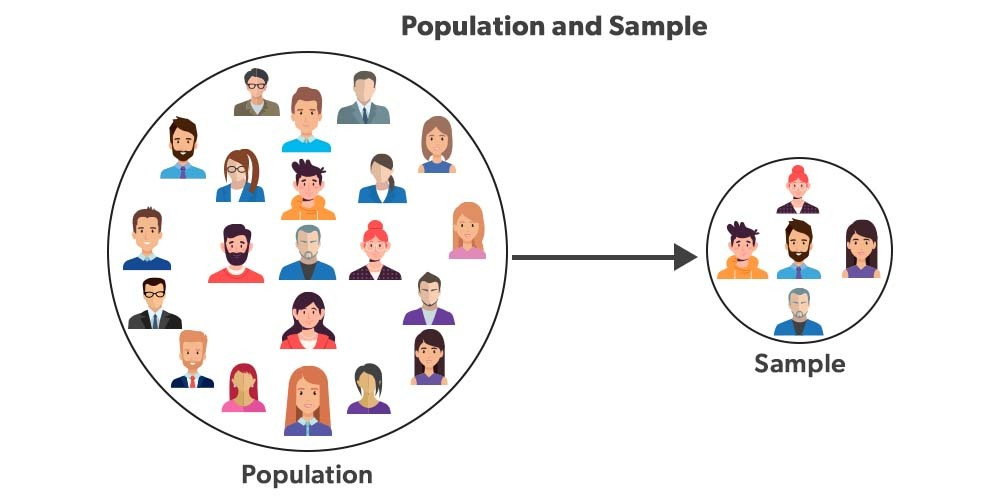

### Population

A **population** refers to the entire set of individuals or items that we are interested in studying.

- **Example**: Calculating the *true* average height of all adult women in a country would require measuring every adult woman in the country.

### Sample

A **sample** is a subset of the population, selected for practical reasons, from which we infer characteristics of the entire population.

- **Example**: Studying the height of 1,000 randomly selected adult women from a part of the country.

**Tip**Population vs. Sample**

| **Population** | **Sample** |
| --- | --- |
| Includes all members of a specified group | Subset of the population |
| Often impractical to study entirely | Practical and feasible to study |
| Example: All residents in France | Example: 1,000 randomly chosen residents in Paris |

We can almost never measure every single unit in a population, so we use sample data to **estimate** the true population parameters.

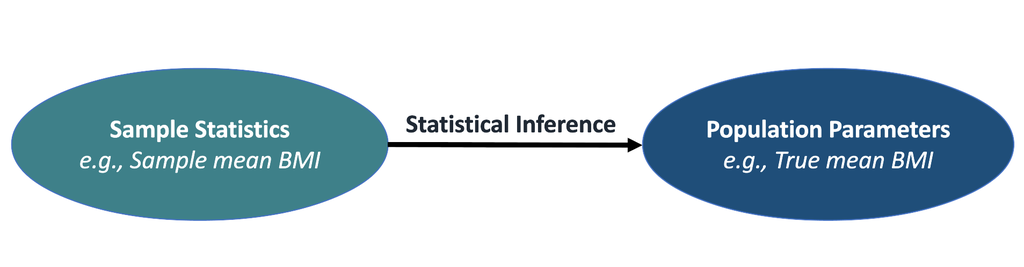

# Load Packages

```r
# Load packages - we use p_load from pacman, which loads and installs as needed.
# tidyverse: data manipulation & ggplot2
# here: project-relative file paths
# janitor: frequency tables (tabyl)
# inspectdf & visdat: data exploration and visualization
pacman::p_load(tidyverse,
               here,
               janitor,
               visdat)

# inspectdf was removed from CRAN, so we install from a custom GitHub fork
pacman::p_load_current_gh("the-graph-courses/inspectdf")
```

# The Yaounde COVID-19 dataset

In this lesson, we analyse results from a COVID-19 serological survey conducted in Yaounde, Cameroon in late 2020. The survey estimated how many people had been infected with COVID-19 in the region, by testing for IgG and IgM antibodies. The full dataset can be obtained from [Zenodo](https://zenodo.org/record/5218965), and the paper can be viewed [here](https://www.nature.com/articles/s41467-021-25946-0).

Spend some time browsing through this dataset. Each line corresponds to one patient surveyed. There are some demographic, socio-economic and COVID-related variables. The results of the IgG and IgM antibody tests are in the columns `igg_result` and `igm_result`.

```r
# Import data to RStudio
yaounde <- read_csv(here("data/yaounde_data.csv"))
```

We can use `spec()` to retrieve the full column specification, showing the R data class for each of the 53 variables.

```r
spec(yaounde)
```

Let’s spend some time browsing through this dataset.

```r
# View first 6 rows of the dataframe
head(yaounde)
```

```
# A tibble: 6 × 53
  id     date_surveyed   age age_category age_category_3 sex   highest_education
  <chr>  <date>        <dbl> <chr>        <chr>          <chr> <chr>
1 BRIQU… 2020-10-22       45 45 - 64      Adult          Fema… Secondary
2 BRIQU… 2020-10-24       55 45 - 64      Adult          Male  University
3 BRIQU… 2020-10-24       23 15 - 29      Adult          Male  University
4 BRIQU… 2020-10-22       20 15 - 29      Adult          Fema… Secondary
5 BRIQU… 2020-10-22       55 45 - 64      Adult          Fema… Primary
6 BRIQU… 2020-10-25       17 15 - 29      Child          Fema… Secondary
# ℹ 46 more variables: occupation <chr>, weight_kg <dbl>, height_cm <dbl>,
#   is_smoker <chr>, is_pregnant <chr>, is_medicated <chr>, neighborhood <chr>,
#   household_with_children <chr>, breadwinner <chr>, source_of_revenue <chr>,
#   has_contact_covid <chr>, igg_result <chr>, igm_result <chr>,
#   symptoms <chr>, symp_fever <chr>, symp_headache <chr>, symp_cough <chr>,
#   symp_rhinitis <chr>, symp_sneezing <chr>, symp_fatigue <chr>,
#   symp_muscle_pain <chr>, symp_nausea_or_vomiting <chr>, …
```

To view the entire data frame in a spreadsheet-style viewer, we can use the `view()` function (or click on the dataset name in the Environment tab in RStudio):

```r
view(yaounde)
```

Browsing through the data, you’ll notice that most variables contain words (categorical), some contain only 0s and 1s (binary), and a few contain continuous numbers like `age`, `height_cm`, and `weight_kg`.

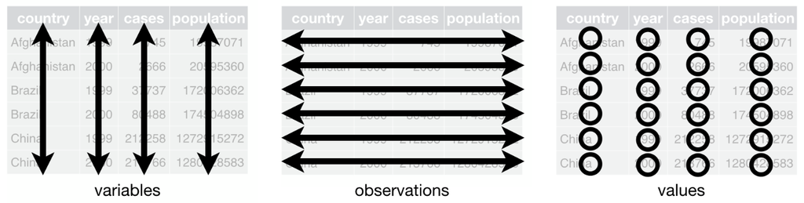

- Each row corresponds to one patient surveyed.
- There are some demographic, socio-economic and COVID-related variables.
- The results of the IgG and IgM antibody tests are in the columns `igg_result` and `igm_result`.

We can view the data classes of these variables using the `str()` function, which shows the structure of the data frame in a compact format.

```r
# View variable data classes
str(yaounde)
```

```
spc_tbl_ [971 × 53] (S3: spec_tbl_df/tbl_df/tbl/data.frame)
 $ id                       : chr [1:971] "BRIQUETERIE_000_0001" "BRIQUETERIE_000_0002" "BRIQUETERIE_000_0003" "BRIQUETERIE_002_0001" ...
 $ date_surveyed            : Date[1:971], format: "2020-10-22" "2020-10-24" ...
 $ age                      : num [1:971] 45 55 23 20 55 17 13 28 30 13 ...
 $ age_category             : chr [1:971] "45 - 64" "45 - 64" "15 - 29" "15 - 29" ...
 $ age_category_3           : chr [1:971] "Adult" "Adult" "Adult" "Adult" ...
 $ sex                      : chr [1:971] "Female" "Male" "Male" "Female" ...
 $ highest_education        : chr [1:971] "Secondary" "University" "University" "Secondary" ...
 $ occupation               : chr [1:971] "Informal worker" "Salaried worker" "Student" "Student" ...
 $ weight_kg                : num [1:971] 95 96 74 70 67 65 65 62 73 56 ...
 $ height_cm                : num [1:971] 169 185 180 164 147 162 150 173 170 153 ...
 $ is_smoker                : chr [1:971] "Non-smoker" "Ex-smoker" "Smoker" "Non-smoker" ...
 $ is_pregnant              : chr [1:971] "No" NA NA "No" ...
 $ is_medicated             : chr [1:971] "Yes" "No" "Yes" "No" ...
 $ neighborhood             : chr [1:971] "Briqueterie" "Briqueterie" "Briqueterie" "Briqueterie" ...
 $ household_with_children  : chr [1:971] "No children" "No children" "No children" "With children" ...
 $ breadwinner              : chr [1:971] "No response" "Other family" "No response" "Mother" ...
 $ source_of_revenue        : chr [1:971] "Other" "Regular, Formal--Regular, Commerce" "Other" "Irregular, Commerce" ...
 $ has_contact_covid        : chr [1:971] "Recent COVID contact" "No COVID contact" "No COVID contact" "No COVID contact" ...
 $ igg_result               : chr [1:971] "Negative" "Positive" "Negative" "Positive" ...
 $ igm_result               : chr [1:971] "Negative" "Negative" "Negative" "Negative" ...
 $ symptoms                 : chr [1:971] "Muscle pain" "No symptoms" "No symptoms" "Rhinitis--Sneezing--Anosmia or ageusia" ...
 $ symp_fever               : chr [1:971] "No" "No" "No" "No" ...
 $ symp_headache            : chr [1:971] "No" "No" "No" "No" ...
 $ symp_cough               : chr [1:971] "No" "No" "No" "No" ...
 $ symp_rhinitis            : chr [1:971] "No" "No" "No" "Yes" ...
 $ symp_sneezing            : chr [1:971] "No" "No" "No" "Yes" ...
 $ symp_fatigue             : chr [1:971] "No" "No" "No" "No" ...
 $ symp_muscle_pain         : chr [1:971] "Yes" "No" "No" "No" ...
 $ symp_nausea_or_vomiting  : chr [1:971] "No" "No" "No" "No" ...
 $ symp_diarrhoea           : chr [1:971] "No" "No" "No" "No" ...
 $ symp_short_breath        : chr [1:971] "No" "No" "No" "No" ...
 $ symp_sore_throat         : chr [1:971] "No" "No" "No" "No" ...
 $ symp_anosmia_or_ageusia  : chr [1:971] "No" "No" "No" "Yes" ...
 $ symp_stomach_ache        : chr [1:971] "No" "No" "No" "No" ...
 $ n_days_miss_work         : num [1:971] 0 NA NA 7 NA 7 0 0 0 NA ...
 $ n_bedridden_days         : num [1:971] 0 NA NA 7 NA 3 0 1 0 NA ...
 $ consultation             : chr [1:971] NA NA NA NA ...
 $ treatment_combinations   : chr [1:971] "Paracetamol" NA NA "Antibiotics" ...
 $ drugsource               : chr [1:971] "Self or familial" NA NA "Self or familial" ...
```

[output cut: 56 more lines]

```
  ..   sequelae = col_character(),
  ..   respiration_frequency = col_double(),
  ..   is_drug_parac = col_double(),
  ..   is_drug_antibio = col_double(),
  ..   is_drug_hydrocortisone = col_double(),
  ..   is_drug_other_anti_inflam = col_double(),
  ..   is_drug_antiviral = col_double(),
  ..   is_drug_chloro = col_double(),
  ..   is_drug_tradn = col_double(),
  ..   is_drug_oxygen = col_double(),
  ..   is_drug_other = col_double(),
  ..   is_drug_no_resp = col_double(),
  ..   is_drug_none = col_double()
  .. )
 - attr(*, "problems")=<pointer: 0x00000223ff3fe980>
```

The `glimpse()` function from {dplyr} gives a similar but slightly more readable view. It shows each variable name, its data class, and the first few values:

```r
glimpse(yaounde)
```

```
Rows: 971
Columns: 53
$ id                        <chr> "BRIQUETERIE_000_0001", "BRIQUETERIE_000_000…
$ date_surveyed             <date> 2020-10-22, 2020-10-24, 2020-10-24, 2020-10…
$ age                       <dbl> 45, 55, 23, 20, 55, 17, 13, 28, 30, 13, 62, …
$ age_category              <chr> "45 - 64", "45 - 64", "15 - 29", "15 - 29", …
$ age_category_3            <chr> "Adult", "Adult", "Adult", "Adult", "Adult",…
$ sex                       <chr> "Female", "Male", "Male", "Female", "Female"…
$ highest_education         <chr> "Secondary", "University", "University", "Se…
$ occupation                <chr> "Informal worker", "Salaried worker", "Stude…
$ weight_kg                 <dbl> 95, 96, 74, 70, 67, 65, 65, 62, 73, 56, 53, …
$ height_cm                 <dbl> 169, 185, 180, 164, 147, 162, 150, 173, 170,…
$ is_smoker                 <chr> "Non-smoker", "Ex-smoker", "Smoker", "Non-sm…
$ is_pregnant               <chr> "No", NA, NA, "No", "No", "No", "No", NA, NA…
$ is_medicated              <chr> "Yes", "No", "Yes", "No", "No", "No", "No", …
```

[output cut: 40 more lines]

Note that `glimpse()` reports numeric variables as `<dbl>` (double, for values that can include decimals) or `<int>` (integer, for whole numbers only). Character variables (with text values) are shown as `<chr>`. R does not automatically know whether a categorical variable is ordinal or not - all text variables come in as `<chr>` by default, and we’ll convert specific ones to ordered factors later in the lesson.

We can also visualize the R data type of each variable in our dataset using `vis_dat()` from the {visdat} package. Each column represents a column in our data frame, and the color tells us the R data class.

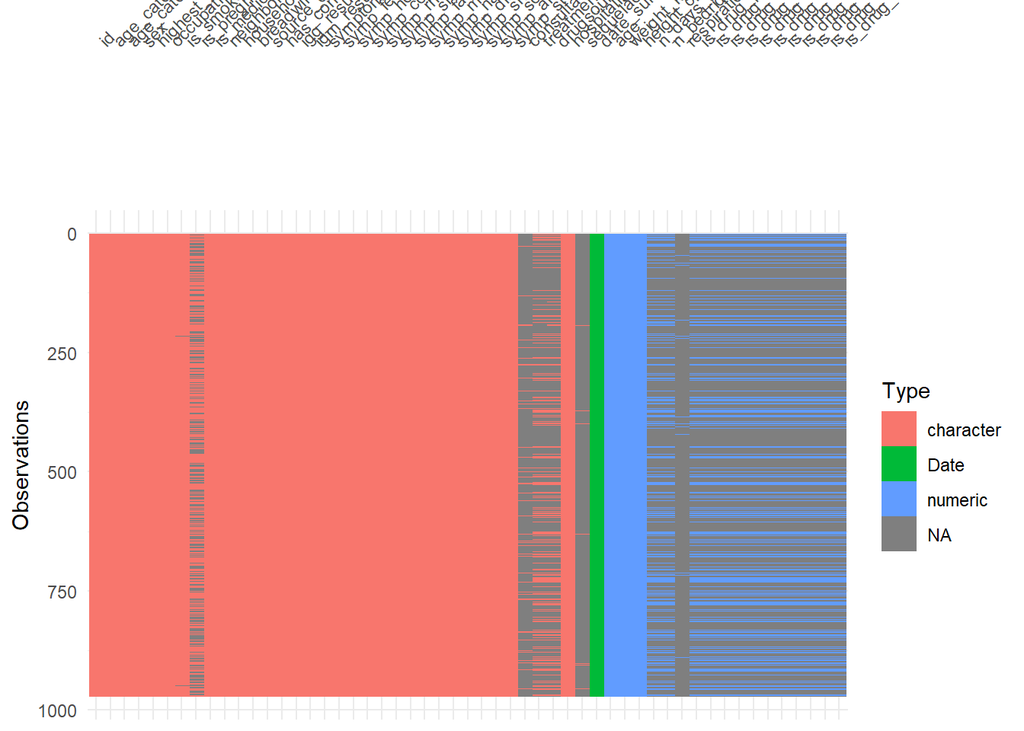

```r
# VISUALIZE DATA TYPE OF EACH VARIABLE
vis_dat(yaounde)
```

We can further investigate just the categorical and the numeric variables separately using functions from {inspectdf}.

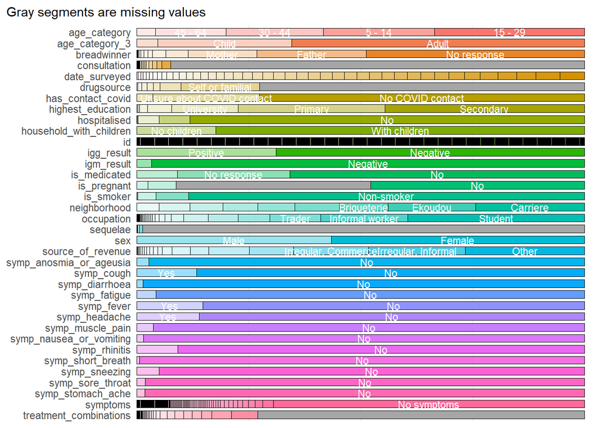

```r
# INSPECT CATEGORICAL VARIABLES
yao_cat_summary <- inspect_cat(yaounde)
show_plot(yao_cat_summary)
```

**Tip**

In RStudio, you can click on `yao_cat_summary` in the Environment tab and then click on the `levels` column to see the exact count for every category of each variable (e.g., 635 adults, 291 children, 45 seniors in `age_category_3`).

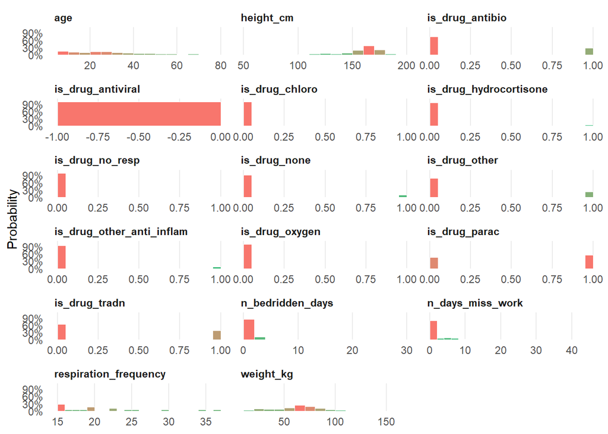

```r
# INSPECT NUMERIC VARIABLES
yao_num_summary <- inspect_num(yaounde)
show_plot(yao_num_summary)
```

Notice that some “is_drug” variables show up as numeric (with 0s and 1s) even though they are really binary categorical variables. We can convert them to logical type using `as.logical()`.

```r
# Convert "is_drug" variables to logical
yao2 <- yaounde %>%
  mutate(across(starts_with("is_drug"), as.logical))
```

Now if we re-run `inspect_num()` on `yao2`, we see histograms of only the true numeric variables:

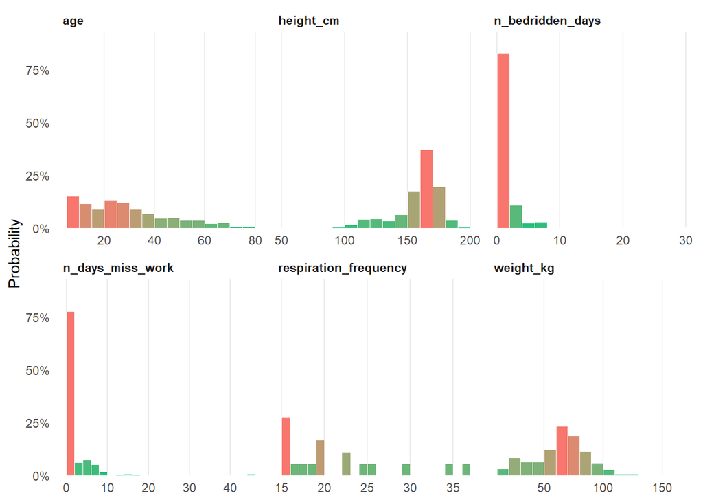

```r
show_plot(inspect_num(yao2))
```

We can also look at `vis_dat()` again to see the data types after conversion:

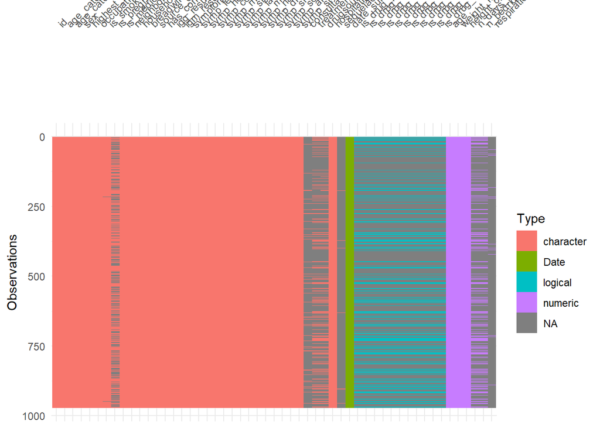

```r
vis_dat(yao2)
```

Now let’s use `mutate()` to convert several variables to their correct R data classes all at once:

```r
yaounde <- yaounde %>%
  mutate(across(starts_with("is_drug"), as.logical),
         across(starts_with("n_"), as.integer),
         age_category_3 = factor(age_category_3,
                                 levels = c("Child", "Adult", "Senior")),
         is_smoker = factor(is_smoker,
                            levels = c("Non-smoker", "Ex-smoker", "Smoker")),
         highest_education = factor(highest_education,
                                    levels = c("No formal instruction",
                                               "Primary",
                                               "Secondary",
                                               "University",
                                               "Doctorate",
                                               "No response"))
         )
```

Let’s verify the changes using `vis_dat()`:

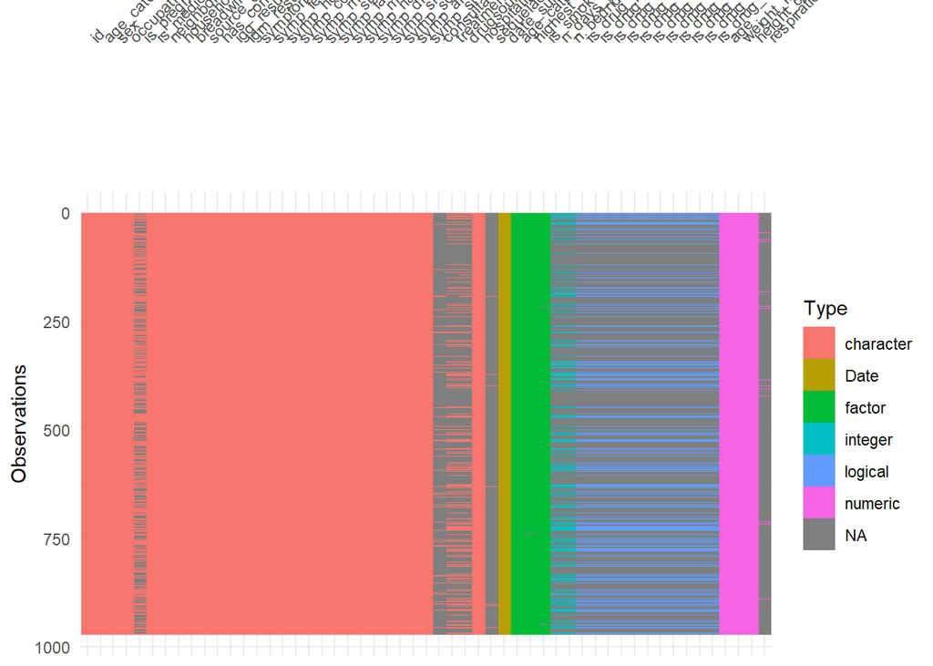

```r
vis_dat(yaounde)
```

We can also use `inspect_types()` from {inspectdf} to get a summary of the different variable types in our data frame:

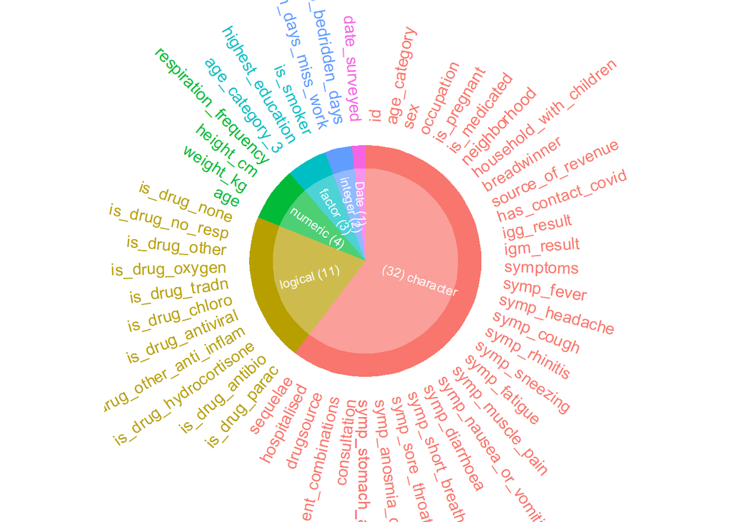

```r
show_plot(inspect_types(yaounde))
```

**TipWhat is a variable?**

A variable is something we can observe or study, a feature of individual units (e.g., humans) in our data.

# Variable Types

When conducting descriptive analysis, the method you choose will depend on the *type* of data you’re analyzing. At the most basic level, variables can be described as numerical or categorical.

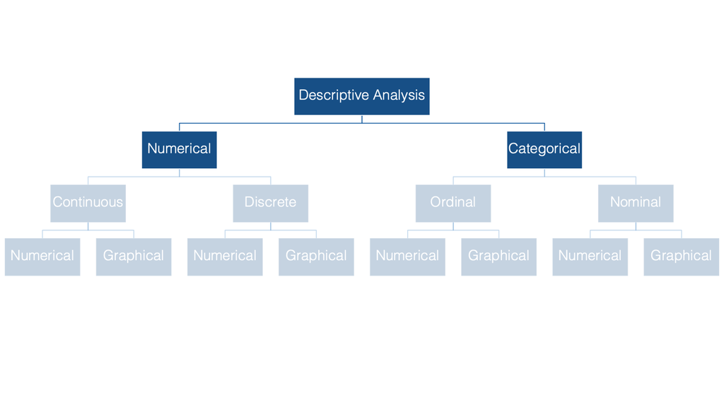

Numeric variables can then be further divided into **continuous** and **discrete** - the distinction being whether the variable can take on a continuum of values (e.g., height or weight), or only set of certain values (e.g., age or year).

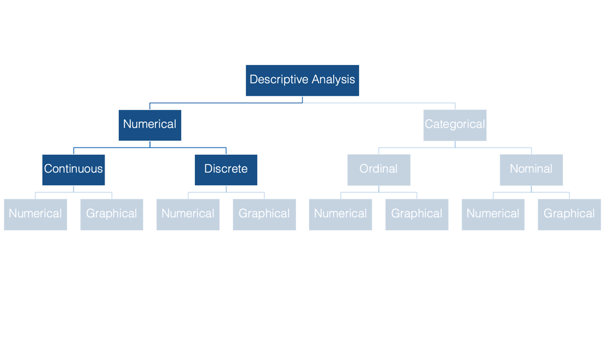

Categorical variables can be subdivided into **ordinal** or **nominal** variables - depending on whether or not the categories can logically be ordered in a meaningful way.

Some examples of categorical variables seen in our `yaounde` data frame are: `sex`, `highest_education`, and `age_category`. In fact, most of the variables in this dataset are categorical.

```r
head(yaounde)
```

| id | date_surveyed | age | age_category | age_category_3 | sex | highest_education | occupation | weight_kg | height_cm | is_smoker | is_pregnant | is_medicated | neighborhood | household_with_children | breadwinner | source_of_revenue | has_contact_covid | igg_result | igm_result | symptoms | symp_fever | symp_headache | symp_cough | symp_rhinitis | symp_sneezing | symp_fatigue | symp_muscle_pain | symp_nausea_or_vomiting | symp_diarrhoea | … |
| --- | --- | --- | --- | --- | --- | --- | --- | --- | --- | --- | --- | --- | --- | --- | --- | --- | --- | --- | --- | --- | --- | --- | --- | --- | --- | --- | --- | --- | --- | --- |
| BRIQUETERIE_000_0001 | 2020-10-22 | 45 | 45 - 64 | Adult | Female | Secondary | Informal worker | 95 | 169 | Non-smoker | No | Yes | Briqueterie | No children | No response | Other | Recent COVID contact | Negative | Negative | Muscle pain | No | No | No | No | No | No | Yes | No | No | … |
| BRIQUETERIE_000_0002 | 2020-10-24 | 55 | 45 - 64 | Adult | Male | University | Salaried worker | 96 | 185 | Ex-smoker | NA | No | Briqueterie | No children | Other family | Regular, Formal--Regular, Commerce | No COVID contact | Positive | Negative | No symptoms | No | No | No | No | No | No | No | No | No | … |
| BRIQUETERIE_000_0003 | 2020-10-24 | 23 | 15 - 29 | Adult | Male | University | Student | 74 | 180 | Smoker | NA | Yes | Briqueterie | No children | No response | Other | No COVID contact | Negative | Negative | No symptoms | No | No | No | No | No | No | No | No | No | … |
| BRIQUETERIE_002_0001 | 2020-10-22 | 20 | 15 - 29 | Adult | Female | Secondary | Student | 70 | 164 | Non-smoker | No | No | Briqueterie | With children | Mother | Irregular, Commerce | No COVID contact | Positive | Negative | Rhinitis--Sneezing--Anosmia or ageusia | No | No | No | Yes | Yes | No | No | No | No | … |
| BRIQUETERIE_002_0002 | 2020-10-22 | 55 | 45 - 64 | Adult | Female | Primary | Trader--Farmer | 67 | 147 | Non-smoker | No | No | Briqueterie | With children | Mother | Regular, Informal--Irregular, Commerce--Other | No COVID contact | Positive | Negative | No symptoms | No | No | No | No | No | No | No | No | No | … |
| BRIQUETERIE_002_0003 | 2020-10-25 | 17 | 15 - 29 | Child | Female | Secondary | Student | 65 | 162 | Non-smoker | No | No | Briqueterie | With children | No response | Irregular, Commerce | No COVID contact | Negative | Negative | Fever--Cough--Rhinitis--Nausea or vomiting--Diarrhoea | Yes | No | Yes | Yes | No | No | No | Yes | Yes | … |

Can you identify which variables are numeric? Of those, which are continuous and which are discrete? The `glimpse()` function can help us get a better look at this.

```r
glimpse(yaounde)
```

```
Rows: 971
Columns: 53
$ id                        <chr> "BRIQUETERIE_000_0001", "BRIQUETERIE_000_000…
$ date_surveyed             <date> 2020-10-22, 2020-10-24, 2020-10-24, 2020-10…
$ age                       <dbl> 45, 55, 23, 20, 55, 17, 13, 28, 30, 13, 62, …
$ age_category              <chr> "45 - 64", "45 - 64", "15 - 29", "15 - 29", …
$ age_category_3            <fct> Adult, Adult, Adult, Adult, Adult, Child, Ch…
$ sex                       <chr> "Female", "Male", "Male", "Female", "Female"…
$ highest_education         <fct> Secondary, University, University, Secondary…
$ occupation                <chr> "Informal worker", "Salaried worker", "Stude…
$ weight_kg                 <dbl> 95, 96, 74, 70, 67, 65, 65, 62, 73, 56, 53, …
$ height_cm                 <dbl> 169, 185, 180, 164, 147, 162, 150, 173, 170,…
$ is_smoker                 <fct> Non-smoker, Ex-smoker, Smoker, Non-smoker, N…
$ is_pregnant               <chr> "No", NA, NA, "No", "No", "No", "No", NA, NA…
$ is_medicated              <chr> "Yes", "No", "Yes", "No", "No", "No", "No", …
```

[output cut: 40 more lines]

**TipReview of the Main Data Types in R**

Each variable type corresponds to different R data classes/types:

Variable Type

R Data Type

Continuous

`numeric`, specifically `double`

Discrete

`numeric`, specifically `integer`

Nominal

`character`

Ordinal

`factor` (ordered)

Binary

- `numeric`, specifically `integer` with 2 values (e.g., 0 and 1)
- `logical` a.k.a. Boolean (`TRUE` or `FALSE`)
- `character` with 2 values (e.g., “success” and “failure”)
- `factor` with 2 values, (e.g., “low” and “high”)

**NotePractice**

**Identifying Variable Types and R Data classes**

For each of the following variables, in the `yaounde` data frame, identify:

(1) the variable type (categorical or numerical),

(2) its subtype (e.g., nominal, ordinal, discrete, continuous), and

(3) the corresponding R data class.

1. `age`
2. `highest_education`
3. `is_smoker`
4. `date_surveyed`
5. `weight_kg`
6. `igg_result`

**NotePractice**

**Reordering the `age_category` variable**

The `age_category` variable (the 5-level version) is currently a character variable, so ggplot sorts it alphabetically on bar charts. Use `mutate()` and `factor()` to reorder it by age (youngest to oldest), then re-plot the bar chart to confirm the ordering is correct.

# Methods of Describing Distributions

Variables in a dataset are described by distributions rather than single values.

Remember, we are ultimately aiming to make inferences about populations rather than individuals, so we are not just interested in describing one particular person, but the population as a whole.

How do we describe distributions? One option is to display all the data, but that is not necessarily useful or practical.

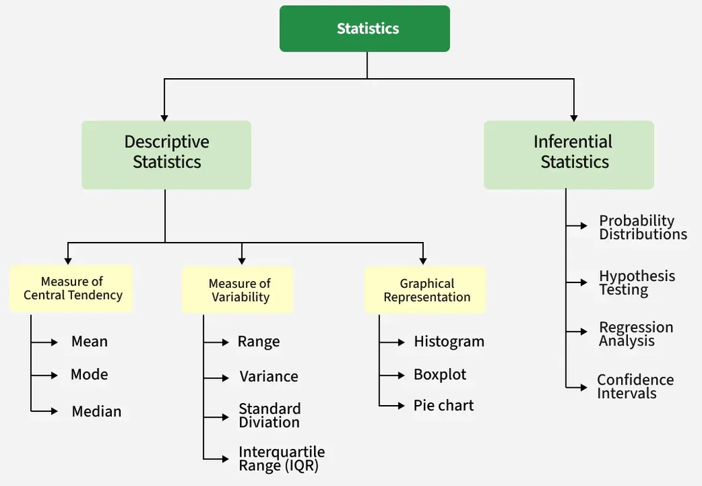

Descriptive analysis of numerical variables can be measured by two different methods: **graphical** or **numerical**. The best way to describe a distribution depends on the type of variable being summarized and its distribution.

**TipHow do we describe distributions?**

There are both **numerical** and **graphical** methods we can use to perform descriptive analysis for all types and subtypes of variables.

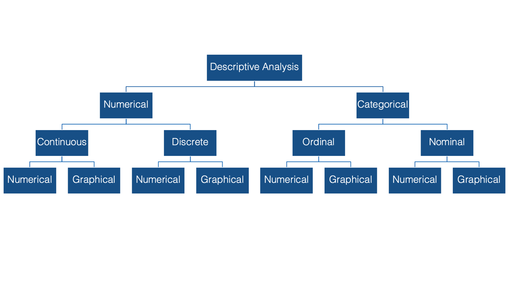

**NotePractice**

**Variable Types (Multiple‑Choice)**

Below are four variables. For each one, indicate whether it is

- **Numerical** (and, if so, whether it is **discrete** or **continuous**)
- **Categorical** (and, if so, whether it is **ordinal** or **nominal**)
1. **Stress level**, with response options “high,” “medium,” and “low.”
2. **Age** in completed years (integer values).
3. **Height** in centimeters.
4. **Country name**

**NotePractice**

**Variable Types (Fill‑in‑the‑Blanks)**

Complete each sentence with the most appropriate term:

1. Quantitative variables are called ________, whereas qualitative variables are called ________.
2. Binary variables have exactly ____ categories.
3. ________ categorical variables contain groups that cannot be meaningfully ordered.
4. Discrete numeric variables consist of whole numbers, also referred to as ________.
5. Long ordinal variables can often be treated as ___________, if they have sufficient categories and are relatively evenly distributed.

# Categorical Variables

We’ll start by describing categorical variables, both numerically and graphically. As a reminder, categorical variables are variables whose values fit into distinct categories.

## Numerical Descriptions of Categorical Variables

We’ll begin our discussion of descriptive statistics in the categorical half of our flow chart. Specifically, we’ll start by numerically describing categorical variables.

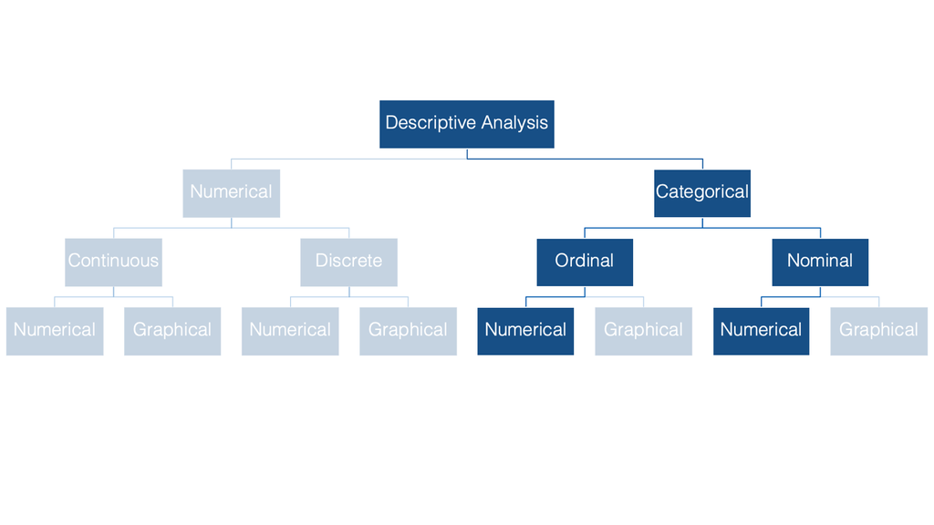

The two most common numerical descriptions of categorical variables are probably the **frequency count** (you will often hear this referred to as simply the frequency, the count, or the n) and the **proportion or percentage** (the percentage is just the proportion multiplied by 100).

Using the `tabyl()` function from the `{janitor}` package, we can make frequency tables displaying the frequencies and percentages of categorical variable(s).

```r
# Make a frequency table of the `is_smoker` variable.
yaounde %>% tabyl(is_smoker)
```

```
  is_smoker   n     percent valid_percent
 Non-smoker 859 0.884654995    0.88648091
  Ex-smoker  71 0.073120494    0.07327141
     Smoker  39 0.040164779    0.04024768
       <NA>   2 0.002059732            NA
```

The `valid_percent` column removes NAs from the denominator. In `is_smoker` there are only a few NAs so this won’t differ much from `percent`, but let’s try it with `is_pregnant`, which has many NAs:

```r
yaounde %>% tabyl(is_pregnant)
```

```
 is_pregnant   n    percent valid_percent
          No 464 0.47785788    0.84517304
 No response  61 0.06282183    0.11111111
         Yes  24 0.02471679    0.04371585
        <NA> 422 0.43460350            NA
```

Now you can see a big difference between `percent` and `valid_percent`. There are 422 NAs in this variable, so although only about 47% of total responses were “No”, 85% of *valid* respondents were not pregnant.

We can also use the `tabyl()` function to create 2-way frequency tables (i.e., contingency tables or cross-tabulations).

```r
# Create a summary data frame of two categorical variables
yaounde %>%
  tabyl(is_smoker, sex)
```

```
  is_smoker Female Male
 Non-smoker    528  331
  Ex-smoker     16   55
     Smoker      4   35
       <NA>      1    1
```

```r
yaounde %>%
  tabyl(is_smoker, sex) %>%
  adorn_percentages("row")
```

```
  is_smoker    Female      Male
 Non-smoker 0.6146682 0.3853318
  Ex-smoker 0.2253521 0.7746479
     Smoker 0.1025641 0.8974359
       <NA> 0.5000000 0.5000000
```

Let’s try this with two other variables. Remember the pregnancy variable had a lot of NAs - is that connected to sex?

```r
yaounde %>%
  tabyl(is_pregnant, sex) %>%
  adorn_percentages("row")
```

```
 is_pregnant Female Male
          No      1    0
 No response      1    0
         Yes      1    0
        <NA>      0    1
```

Looking at the row proportions, we can see that 100% of the NAs are in the male column. To see the raw counts behind this, we can drop `adorn_percentages()`:

```r
yaounde %>%
  tabyl(is_pregnant, sex)
```

```
 is_pregnant Female Male
          No    464    0
 No response     61    0
         Yes     24    0
        <NA>      0  422
```

All 422 NAs were males, which is exactly why the `percent` and `valid_percent` columns differed in the one-way pregnancy table we made earlier.

**NotePractice**

**Frequency Tables**

Use the `tabyl()` function from the `{janitor}` package to answer the following:

1. Create a frequency table of `has_contact_covid`.
2. Create a two-way frequency table between `has_contact_covid` and `igg_result`.
3. Use `adorn_percentages("row")` to display row-wise proportions in the table created above.

## Graphical Descriptions of Categorical Variables

A **bar chart** is the simplest way to graphically describe the distribution of a categorical variable.

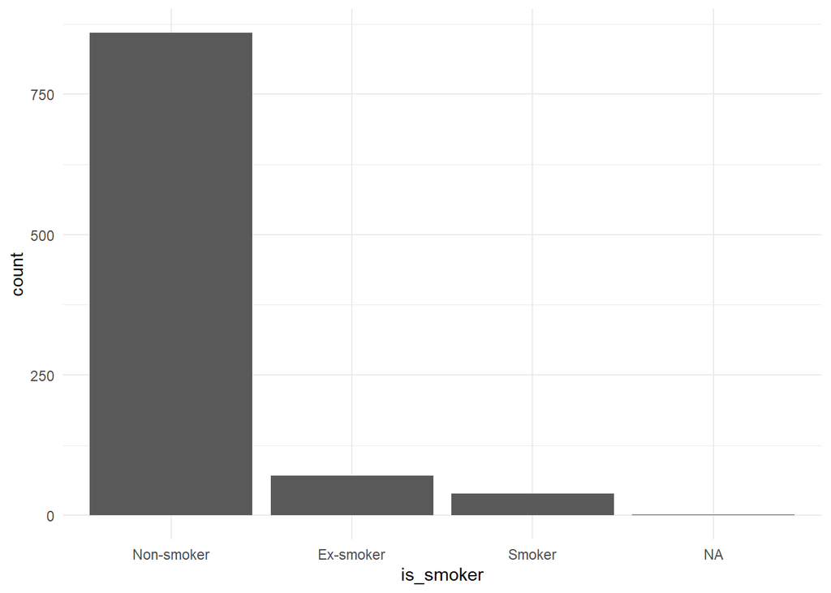

```r
ggplot(yaounde) +
  geom_bar(aes(x = is_smoker))
```

A **stacked bar chart** can help us visualize the distribution of two categorical variables.

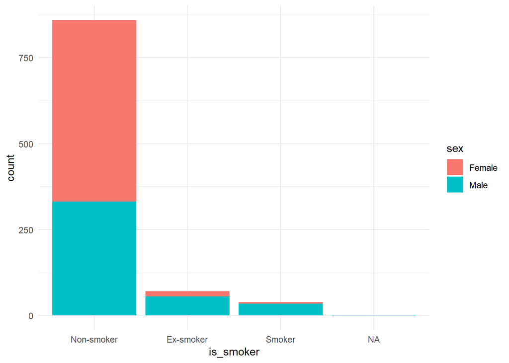

```r
ggplot(yaounde) +
  geom_bar(aes(x = is_smoker, fill = sex))
```

A **percent-stacked bar chart** visualizes them as proportions rather than counts.

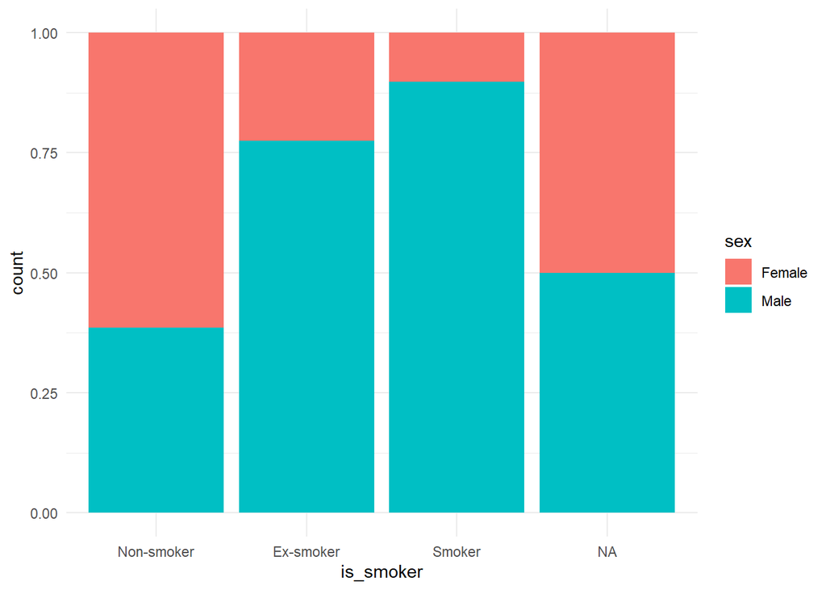

```r
ggplot(yaounde) +
  geom_bar(aes(x = is_smoker, fill = sex),
    position = "fill"
  )
```

We can add count labels inside the bars and total counts above each bar using `geom_text()`:

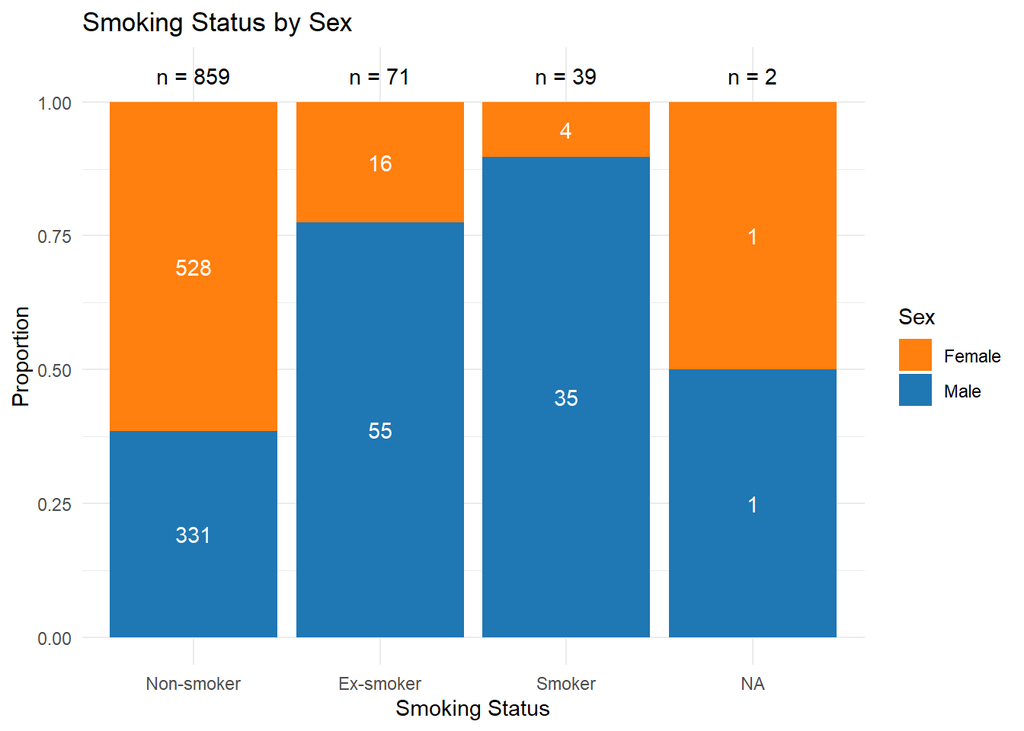

```r
ggplot(yaounde) +
  geom_bar(aes(x = is_smoker, fill = sex),
    position = "fill"
  ) +
  geom_text(
    aes(x = is_smoker, label = after_stat(count), group = sex),
    stat = "count",
    position = position_fill(vjust = 0.5),
    color = "white"
  )  +
  geom_text(
    aes(x = is_smoker, label = paste("n =", after_stat(count))),
    stat = "count",
    position = position_fill(vjust = 1.05)
  ) +
  labs(x = "Smoking Status", y = "Proportion", fill  = "Sex",
    title = "Smoking Status by Sex"
  ) +
  scale_fill_manual(
    values = c("Male" = "#1f77b4", "Female" = "#ff7f0f"))
```

We can also use `position = "dodge"` to create **side-by-side bar charts** instead of stacked:

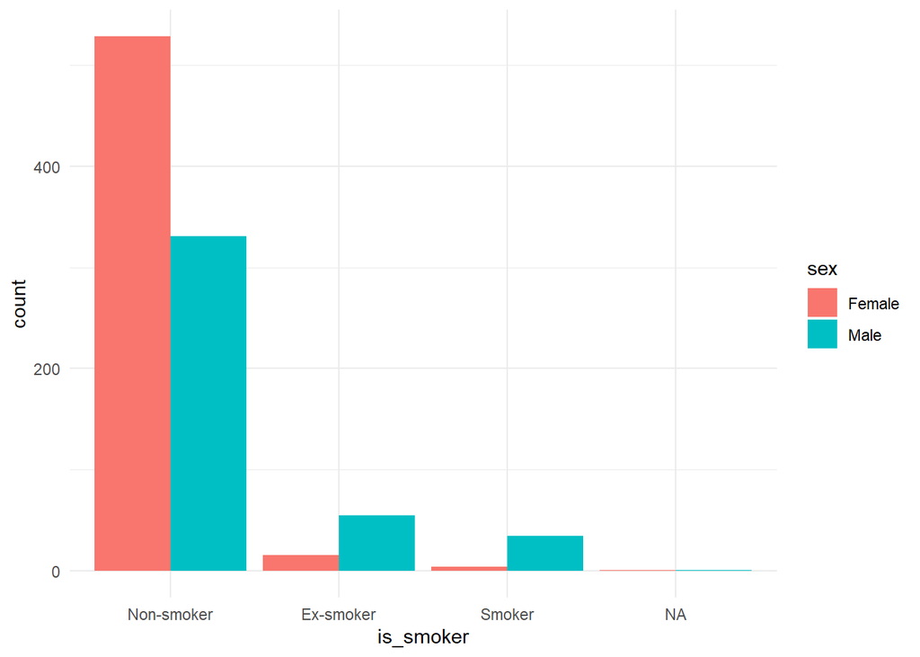

```r
ggplot(yaounde) +
  geom_bar(aes(x = is_smoker, fill = sex),
    position = "dodge"
  )
```

We can also **swap the stratification hierarchy**. So instead of a bar chart of `is_smoker` filled by `sex`, we can make a bar chart of `sex` filled by `is_smoker`:

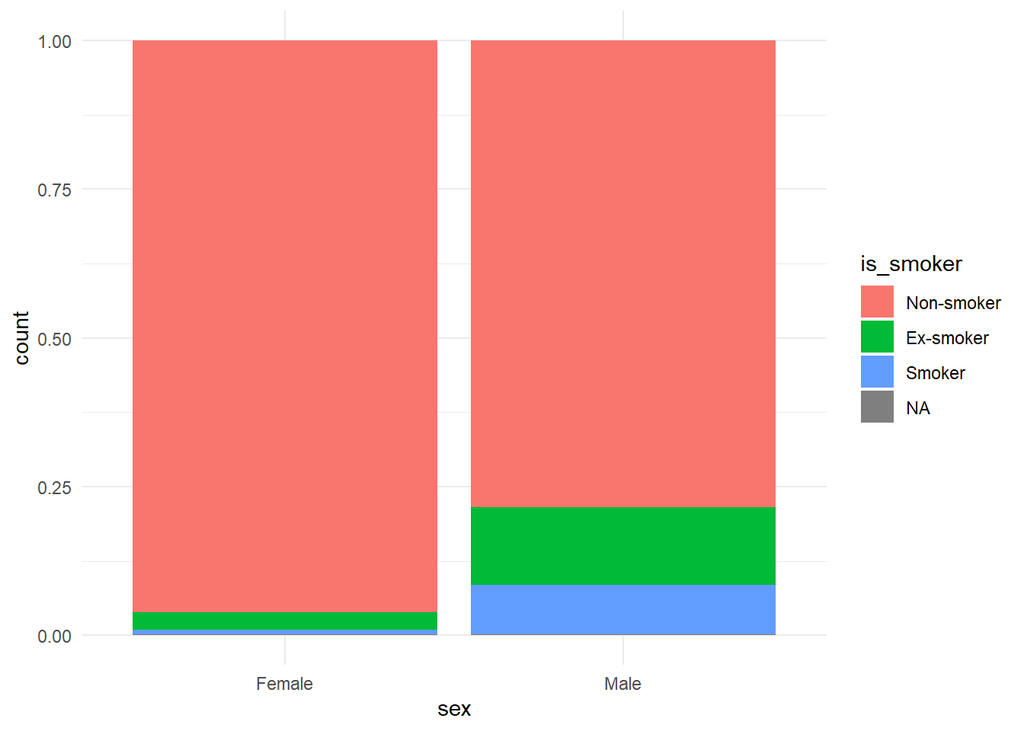

```r
ggplot(yaounde) +
  geom_bar(aes(x = sex, fill = is_smoker),
    position = "fill"
  )
```

It is generally a good idea to look at the data both ways. If the focus of your research is to compare males and females, you’d probably want this graph. If the focus is to compare smokers, ex-smokers, and non-smokers, the previous graph is more appropriate.

**Bar chart of an ordinal variable with ordered categories**

By default, ggplot orders categorical variables alphabetically on the x-axis. Let’s see what happens with `highest_education`:

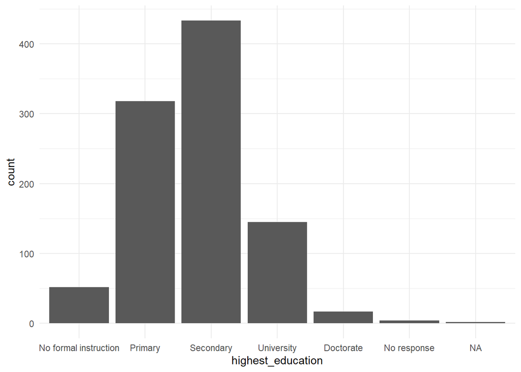

```r
ggplot(yaounde) +
  geom_bar(aes(x = highest_education))
```

Because we already converted `highest_education` to a factor with ordered levels earlier, the categories now appear in a meaningful order (from “No formal instruction” up to “Doctorate”) rather than alphabetically. If we had used `yao2` instead - where `highest_education` is still a character variable - the bars would be sorted alphabetically. This is why setting up factors with the correct level order matters for plotting.

For reference, here is the factor conversion (already done earlier in the lesson):

```r
yaounde <- yaounde %>%
  mutate(
    highest_education =
      factor(highest_education,
        levels = c(
          "No formal instruction",
          "Primary",
          "Secondary",
          "University",
          "Doctorate",
          "No response"
        )
      )
  )
```

**Stratification - compare distributions between categories**

We can stratify the bar chart by sex to compare the distributions of education levels between males and females:

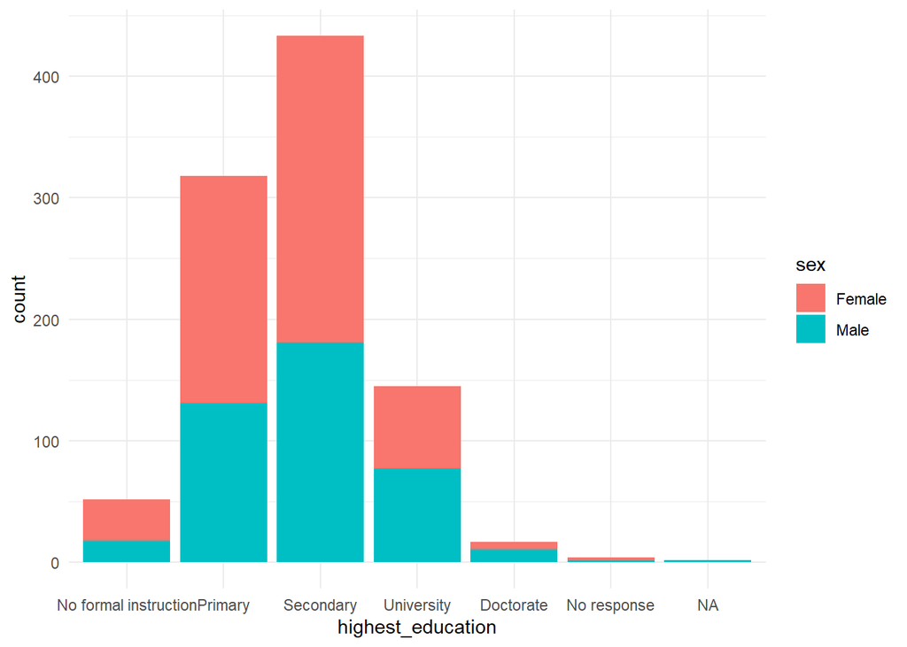

```r
ggplot(yaounde) +
  geom_bar(aes(x = highest_education, fill = sex))
```

We see that secondary education is the most common education level overall. But because the total numbers of males and females in the data aren’t equal, raw counts can be misleading. Let’s switch to proportions:

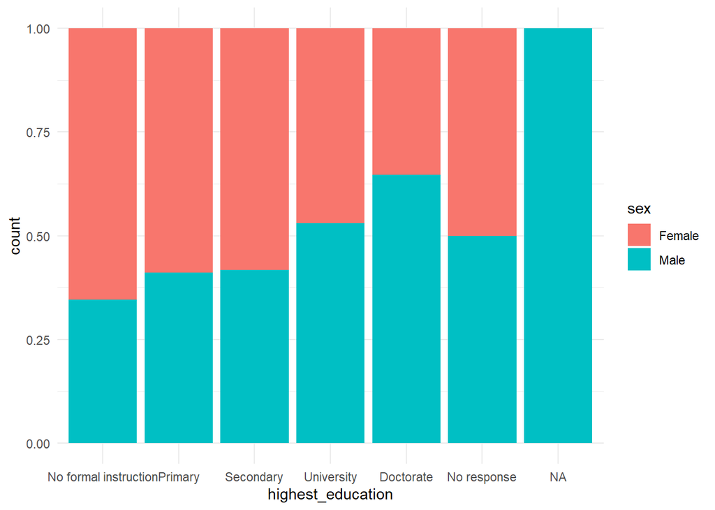

```r
ggplot(yaounde) +
  geom_bar(aes(x = highest_education, fill = sex),
    position = "fill"
  )
```

Now we can see a clear pattern: at the lowest education level (no formal instruction), the bar is mostly female. As we move up through primary, secondary, university, and doctorate, the proportion of males increases and eventually overtakes the proportion of females.

**Swap the stratification hierarchy**

We can also flip which variable is on the x-axis and which is the fill:

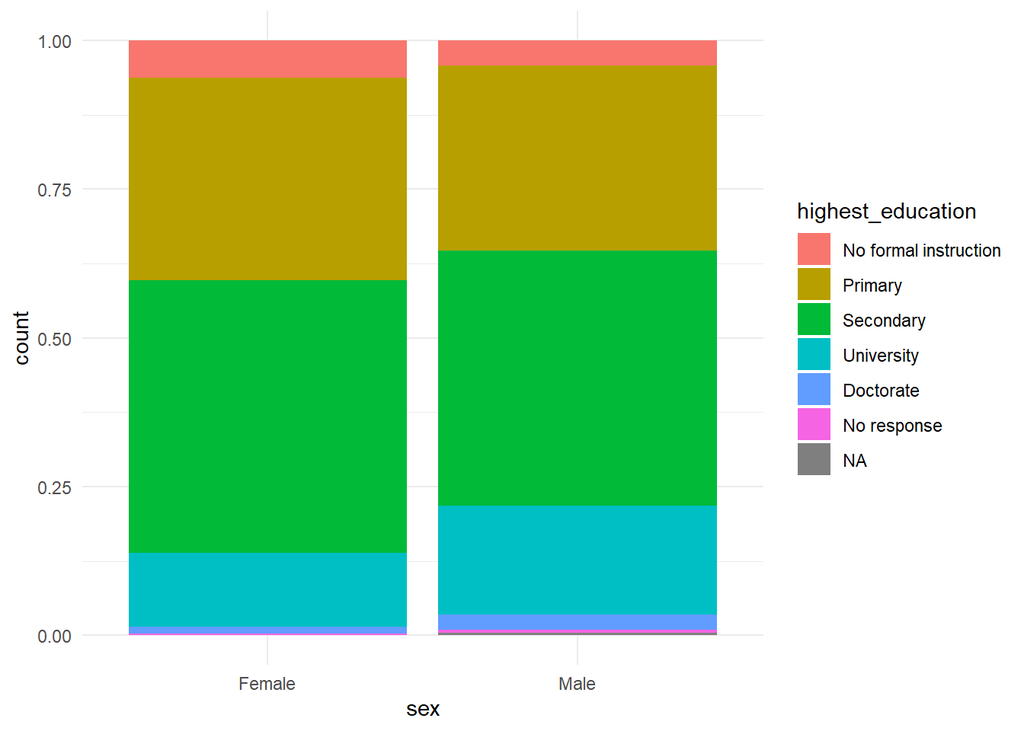

```r
ggplot(yaounde) +
  geom_bar(aes(x = sex, fill = highest_education),
    position = "fill"
  )
```

This view emphasizes the distribution of education levels *within* each sex, rather than the distribution of sexes *within* each education level. As before, the choice depends on which comparison is the focus of your analysis.

**NotePractice**

**Bar Charts**

Use `ggplot()` to create the following charts:

1. Plot a bar chart showing the distribution of `age_category_3`, colored by `igg_result`.
2. Create a percent-stacked bar chart showing the same variables.
3. Add text labels to show the count of individuals in each age group, using `geom_text()`. Customize the look of the plot as desired (titles, labels, and colors).

# Numerical Variables

## Graphical Summaries of Numerical Variables

Visualizations are essential in public health to communicate findings clearly. Two common plots for numerical data are **histograms** and **boxplots**.

### Histograms

A histogram shows how often values fall into specified bins or intervals. This is useful for checking skewness and identifying outliers.

A histogram visualizes the distribution of a numerical value as follows:

1. We first cut up the x-axis into a series of *bins*, where each bin represents a range of values.
2. For each bin, we count the number of observations that fall in the range corresponding to that bin.
3. Then for each bin, we draw a bar whose length marks the corresponding count.

**Tip**

The function for creating histogram in `{ggplot2}` is **`geom_histogram()`**. We can use `fill` and `color` to enhance the appearance of the bars.

Now let’s use {ggplot2} to plot the distribution of heights, which is recorded in the `height_cm` column.

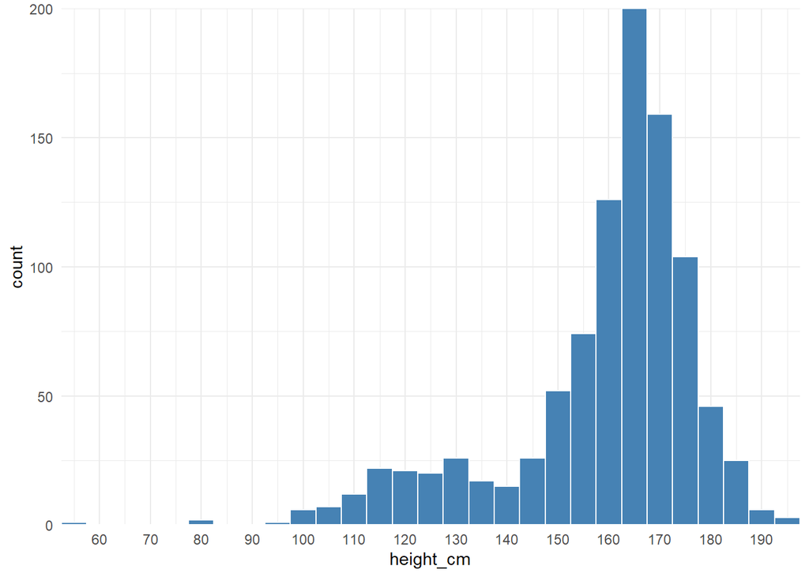

```r
# Histogram showing the distribution of height_cm
ggplot(
  data = yaounde,
  mapping = aes(x = height_cm)
) +
  geom_histogram(
    color = "white",
    fill = "steelblue", binwidth = 5
  ) +
  scale_x_continuous(
    breaks = scales::pretty_breaks(n = 12),
    expand = c(0, 0)
  ) +
  scale_y_continuous(expand = c(0, 0))
```

- The histogram shows **how the probabilities of measurements are distributed**.
- The tallest part of the histogram shows the region where measurements are more likely.
- Most of the measurements come from people between 150 and 180 cm tall.
- This is a slightly left-skewed distribution, probably because of a few children who are on the shorter side.

What if we filter out the children and plot the histogram again?

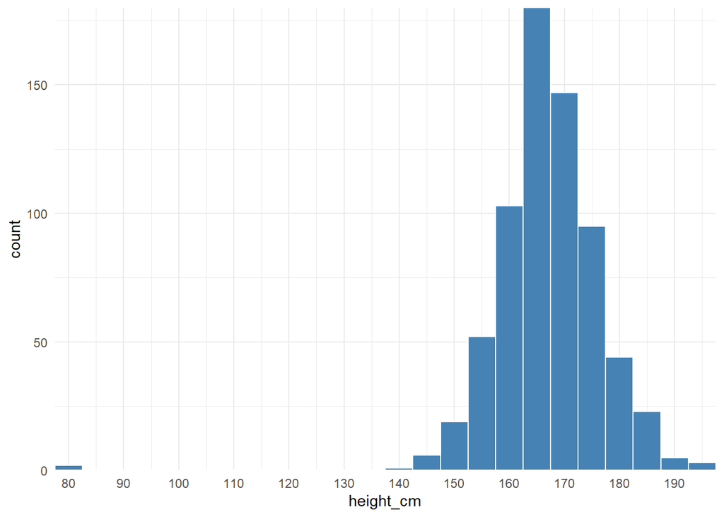

```r
# Create new df of only adults
yao_adults <- yaounde %>% filter(age_category_3 != "Child")

# Define base ggplot layers
yao_adults_height <- ggplot(
  data = yao_adults,
  mapping = aes(x = height_cm)
) +
  scale_x_continuous(
    breaks = scales::pretty_breaks(n = 12),
    expand = c(0, 0)
  ) +
  scale_y_continuous(expand = c(0, 0))

yao_adults_height +
  geom_histogram(
    color = "white",
    fill = "steelblue",
    binwidth = 5
  )
```

- We have a much more normal distribution, which is what you would expect for a variable like height or weight.
- Note the **outliers**: 2 adults under 140 cm.

We can add count labels to each bin using `geom_text()` with `stat = "bin"` to see exact counts:

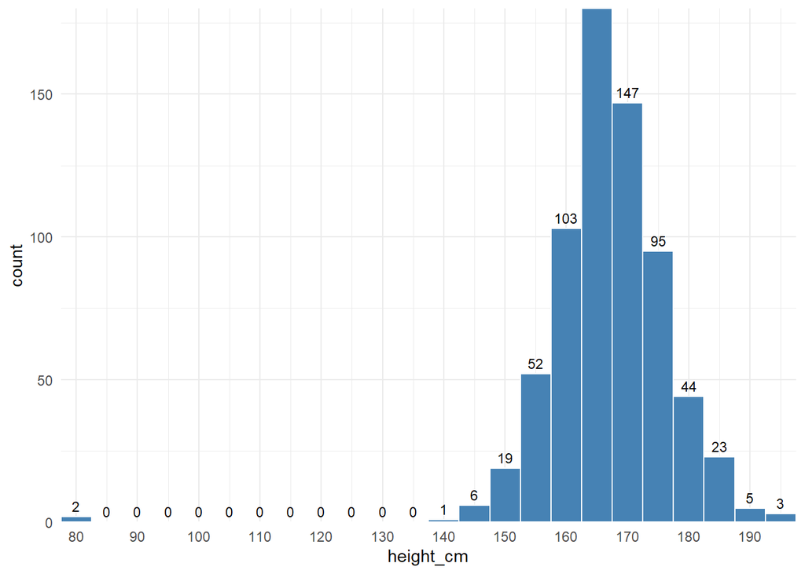

```r
yao_adults_height +
  geom_histogram(
    color = "white",
    fill = "steelblue",
    binwidth = 5
  ) +
  geom_text(
    aes(label = after_stat(count)),
    stat = "bin",
    binwidth = 5,
    vjust = -0.5,
    size = 3
  )
```

If we narrow the x-axis limits, we can see that the distribution is nearly symmetrical without the outliers:

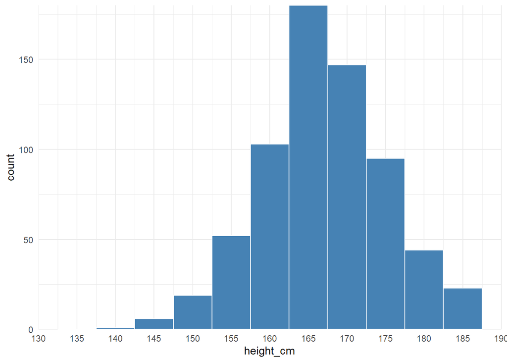

```r
yao_adults_height +
  geom_histogram(
    color = "white",
    fill = "steelblue",
    binwidth = 5
  ) +
  scale_x_continuous(
    breaks = scales::pretty_breaks(n = 12),
    expand = c(0, 0),
    limits = c(130, 190)
  )
```

Note: ggplot will warn that it removed rows outside the scale range. Generally, it is not a good idea to hide parts of your data, but this demonstrates that the outliers are the source of skew.